# Tidyverse Webinar

## Gapminder data

### gapminder

The `gapminder` data set contains demographic statistics popularized by Hans Rosling’s TED talks.

```r
library(gapminder)
gapminder
```

```
## # A tibble: 1,704 x 6
##        country continent  year lifeExp      pop gdpPercap
##         <fctr>    <fctr> <int>   <dbl>    <int>     <dbl>
##  1 Afghanistan      Asia  1952  28.801  8425333  779.4453
##  2 Afghanistan      Asia  1957  30.332  9240934  820.8530
##  3 Afghanistan      Asia  1962  31.997 10267083  853.1007
##  4 Afghanistan      Asia  1967  34.020 11537966  836.1971
##  5 Afghanistan      Asia  1972  36.088 13079460  739.9811
##  6 Afghanistan      Asia  1977  38.438 14880372  786.1134
##  7 Afghanistan      Asia  1982  39.854 12881816  978.0114
##  8 Afghanistan      Asia  1987  40.822 13867957  852.3959
##  9 Afghanistan      Asia  1992  41.674 16317921  649.3414
## 10 Afghanistan      Asia  1997  41.763 22227415  635.3414
## # ... with 1,694 more rows
```

### Goal

Which countries had the fastest growing GDP’s between 1952 and 2007?

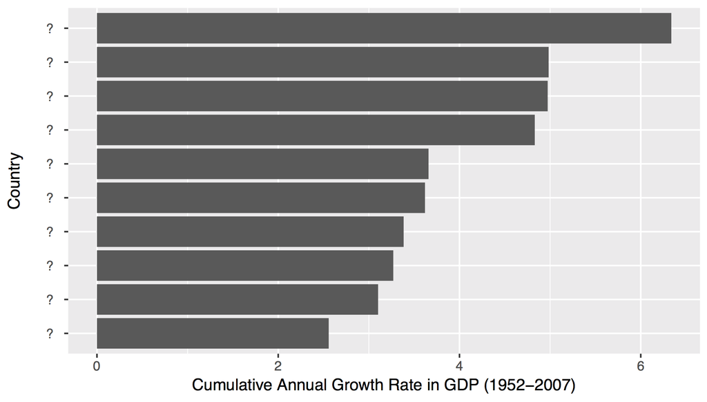

## The Tidyverse

### Functions

In R, you manipulate data by passing the data to functions.

```r
round(1234.567, digits = 2)
```

```
## [1] 1234.57
```

```r
nrow(gapminder)
```

```
## [1] 1704
```

The tidyverse is a collection of R packages that contain functions. You must load the packages to use the functions.

### Load the Tidyverse

```r
## install.packages("tidyverse")
library("tidyverse")
```

### Tidy Tools

Tidyverse functions are designed to be:

1. **Simple** - They do one thing, and they do it well
2. **Composable** - They can be combined with other functions for multi-step operations

### Which countries have the largest populations?

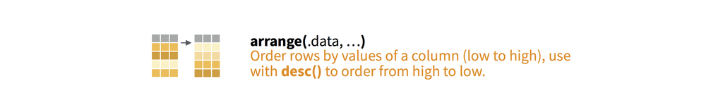

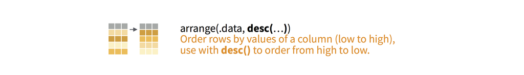

```r
arrange(gapminder, desc(pop))
```

```
## # A tibble: 1,704 x 6
##    country continent  year  lifeExp        pop gdpPercap
##     <fctr>    <fctr> <int>    <dbl>      <int>     <dbl>
##  1   China      Asia  2007 72.96100 1318683096 4959.1149
##  2   China      Asia  2002 72.02800 1280400000 3119.2809
##  3   China      Asia  1997 70.42600 1230075000 2289.2341
##  4   China      Asia  1992 68.69000 1164970000 1655.7842
##  5   India      Asia  2007 64.69800 1110396331 2452.2104
##  6   China      Asia  1987 67.27400 1084035000 1378.9040
##  7   India      Asia  2002 62.87900 1034172547 1746.7695
##  8   China      Asia  1982 65.52500 1000281000  962.4214
##  9   India      Asia  1997 61.76500  959000000 1458.8174
## 10   China      Asia  1977 63.96736  943455000  741.2375
## # ... with 1,694 more rows
```

### Which countries had the largest population *in 2007*?

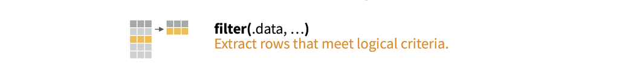

```r
gapminder2007 <- filter(gapminder, year == 2007)
arrange(gapminder2007, desc(pop))
```

```
## # A tibble: 142 x 6
##          country continent  year lifeExp        pop gdpPercap
##           <fctr>    <fctr> <int>   <dbl>      <int>     <dbl>
##  1         China      Asia  2007  72.961 1318683096  4959.115
##  2         India      Asia  2007  64.698 1110396331  2452.210
##  3 United States  Americas  2007  78.242  301139947 42951.653
##  4     Indonesia      Asia  2007  70.650  223547000  3540.652
##  5        Brazil  Americas  2007  72.390  190010647  9065.801
##  6      Pakistan      Asia  2007  65.483  169270617  2605.948
##  7    Bangladesh      Asia  2007  64.062  150448339  1391.254
##  8       Nigeria    Africa  2007  46.859  135031164  2013.977
##  9         Japan      Asia  2007  82.603  127467972 31656.068
## 10        Mexico  Americas  2007  76.195  108700891 11977.575
## # ... with 132 more rows
```

### A better way

Use the pipe operator (%>%) to compose tidyverse functions.

```r
gapminder %>%
  filter(year == 2007) %>%
  arrange(desc(pop))
```

```
## # A tibble: 142 x 6
##          country continent  year lifeExp        pop gdpPercap
##           <fctr>    <fctr> <int>   <dbl>      <int>     <dbl>
##  1         China      Asia  2007  72.961 1318683096  4959.115
##  2         India      Asia  2007  64.698 1110396331  2452.210
##  3 United States  Americas  2007  78.242  301139947 42951.653
##  4     Indonesia      Asia  2007  70.650  223547000  3540.652
##  5        Brazil  Americas  2007  72.390  190010647  9065.801
##  6      Pakistan      Asia  2007  65.483  169270617  2605.948
##  7    Bangladesh      Asia  2007  64.062  150448339  1391.254
##  8       Nigeria    Africa  2007  46.859  135031164  2013.977
##  9         Japan      Asia  2007  82.603  127467972 31656.068
## 10        Mexico  Americas  2007  76.195  108700891 11977.575
## # ... with 132 more rows
```

### Which countries had the largest life expectancy in 2007?

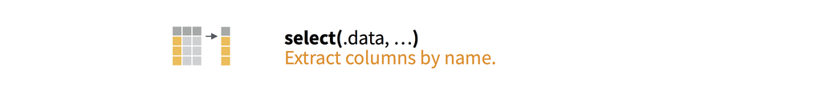

```r
gapminder %>%
  filter(year == 2007) %>%
  arrange(desc(lifeExp)) %>%
  select(country, lifeExp)
```

```
## # A tibble: 142 x 2
##             country lifeExp
##              <fctr>   <dbl>
##  1            Japan  82.603
##  2 Hong Kong, China  82.208
##  3          Iceland  81.757
##  4      Switzerland  81.701
##  5        Australia  81.235
##  6            Spain  80.941
##  7           Sweden  80.884
##  8           Israel  80.745
##  9           France  80.657
## 10           Canada  80.653
## # ... with 132 more rows
```

### What is the gdp of each country?

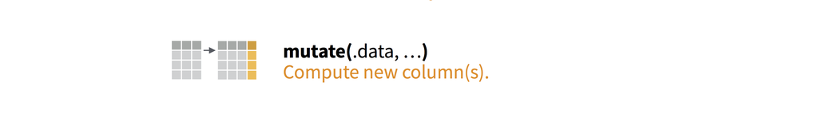

```r
gapminder %>%
  mutate(gdp = pop * gdpPercap)
```

```
## # A tibble: 1,704 x 7
##        country continent  year lifeExp      pop gdpPercap         gdp
##         <fctr>    <fctr> <int>   <dbl>    <int>     <dbl>       <dbl>
##  1 Afghanistan      Asia  1952  28.801  8425333  779.4453  6567086330
##  2 Afghanistan      Asia  1957  30.332  9240934  820.8530  7585448670
##  3 Afghanistan      Asia  1962  31.997 10267083  853.1007  8758855797
##  4 Afghanistan      Asia  1967  34.020 11537966  836.1971  9648014150
##  5 Afghanistan      Asia  1972  36.088 13079460  739.9811  9678553274
##  6 Afghanistan      Asia  1977  38.438 14880372  786.1134 11697659231
##  7 Afghanistan      Asia  1982  39.854 12881816  978.0114 12598563401
##  8 Afghanistan      Asia  1987  40.822 13867957  852.3959 11820990309
##  9 Afghanistan      Asia  1992  41.674 16317921  649.3414 10595901589
## 10 Afghanistan      Asia  1997  41.763 22227415  635.3414 14121995875
## # ... with 1,694 more rows
```

### What was the maximum gdp?

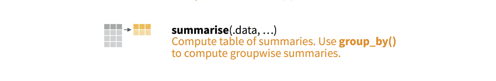

```r
gapminder %>%
  mutate(gdp = pop * gdpPercap) %>%
  summarise(max_gdp = max(gdp))
```

```
## # A tibble: 1 x 1
##        max_gdp
##          <dbl>
## 1 1.293446e+13
```

### What was the first gdp? The last gdp?

```r
gapminder %>%
  mutate(gdp = pop * gdpPercap) %>%
  summarise(first_gdp = first(gdp), last_gdp = last(gdp))
```

```
## # A tibble: 1 x 2
##    first_gdp   last_gdp
##        <dbl>      <dbl>
## 1 6567086330 5782658337
```

### What was the first and last gdp for each country?

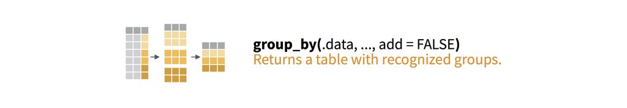

```r
gapminder %>%
  mutate(gdp = pop * gdpPercap) %>%
  group_by(country) %>%
  summarise(first_gdp = first(gdp), last_gdp = last(gdp))
```

```
## # A tibble: 142 x 3
##        country    first_gdp     last_gdp
##         <fctr>        <dbl>        <dbl>
##  1 Afghanistan   6567086330  31079291949
##  2     Albania   2053669902  21376411360
##  3     Algeria  22725632678 207444851958
##  4      Angola  14899557133  59583895818
##  5   Argentina 105676319105 515033625357
##  6   Australia  87256254102 703658358894
##  7     Austria  42516266683 296229400691
##  8     Bahrain   1188460759  21112675360
##  9  Bangladesh  32082059995 209311822134
## 10     Belgium  72838686716 350141166520
## # ... with 132 more rows
```

```r
gapminder %>%
  mutate(gdp = pop * gdpPercap) %>%
  group_by(country) %>%
  summarise(gdp1952 = first(gdp), gdp2007 = last(gdp)) %>%
  mutate(cagr = ((gdp2007 / gdp1952) ^ (1/55) - 1) * 100) %>%
  arrange(desc(cagr)) %>%
  select(country, cagr)
```

```
## # A tibble: 142 x 2
##              country     cagr
##               <fctr>    <dbl>
##  1         Singapore 8.348304
##  2 Equatorial Guinea 8.346729
##  3              Oman 8.218950
##  4            Taiwan 7.869795
##  5          Botswana 7.548170
##  6       Korea, Rep. 7.487215
##  7  Hong Kong, China 7.064369
##  8          Thailand 6.384445
##  9             Libya 6.372590
## 10             China 6.337334
## # ... with 132 more rows
```

### Tidy data

Each tidyverse function expects and returns the same type of data: *tidy data*. A tabular data set is tidy iff:

1. Each variable is in its own column
2. Each observation is in its own row

## Visualization

### What did GDP growth look like?

Let’s focus on the 10 biggest economies (in 1952). What are they?

```r
gapminder %>%
  filter(year == 1952) %>%
  mutate(gdp = pop * gdpPercap) %>%
  arrange(desc(gdp)) %>%
  select(country, gdp)
```

```
## # A tibble: 142 x 2
##           country          gdp
##            <fctr>        <dbl>
##  1  United States 2.204242e+12
##  2 United Kingdom 5.032666e+11
##  3        Germany 4.939866e+11
##  4         France 2.984834e+11
##  5          Japan 2.781349e+11
##  6          Italy 2.350603e+11
##  7          China 2.227550e+11
##  8          India 2.033225e+11
##  9         Canada 1.680701e+11
## 10         Brazil 1.193716e+11
## # ... with 132 more rows
```

### Visualize the Top 10

```r
top_10 <- c("United States", "United Kingdom", "Germany", "France",
            "Japan", "Italy", "China", "India", "Canada", "Brazil")
```

```r
ggplot(data = <DATA>) +
  <GEOM_FUNCTION>(mapping = aes(<MAPPINGS>))
```

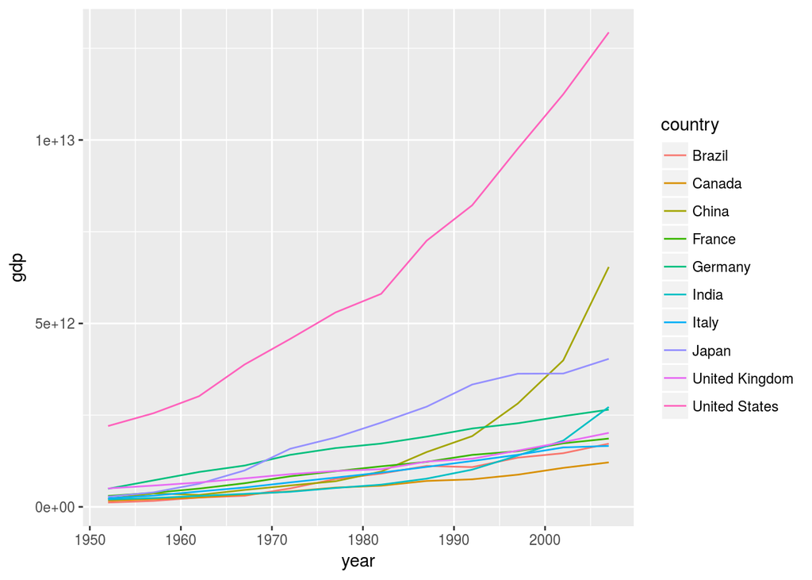

```r
gapminder %>%
  filter(country %in% top_10) %>%
  mutate(gdp = pop * gdpPercap) %>%
  ggplot() +
    geom_line(mapping = aes(x = year, y = gdp, color = country))
```

### Scaled data

Let’s scale the data within each country to make growth easier to compare

```r
gapminder %>%
  filter(country %in% top_10) %>%
  mutate(gdp = pop * gdpPercap)
```

```
## # A tibble: 120 x 7
##    country continent  year lifeExp       pop gdpPercap          gdp
##     <fctr>    <fctr> <int>   <dbl>     <int>     <dbl>        <dbl>
##  1  Brazil  Americas  1952  50.917  56602560  2108.944 1.193716e+11
##  2  Brazil  Americas  1957  53.285  65551171  2487.366 1.630498e+11
##  3  Brazil  Americas  1962  55.665  76039390  3336.586 2.537119e+11
##  4  Brazil  Americas  1967  57.632  88049823  3429.864 3.019989e+11
##  5  Brazil  Americas  1972  59.504 100840058  4985.711 5.027594e+11
##  6  Brazil  Americas  1977  61.489 114313951  6660.119 7.613445e+11
##  7  Brazil  Americas  1982  63.336 128962939  7030.836 9.067173e+11
##  8  Brazil  Americas  1987  65.205 142938076  7807.096 1.115931e+12
##  9  Brazil  Americas  1992  67.057 155975974  6950.283 1.084077e+12
## 10  Brazil  Americas  1997  69.388 168546719  7957.981 1.341292e+12
## # ... with 110 more rows
```

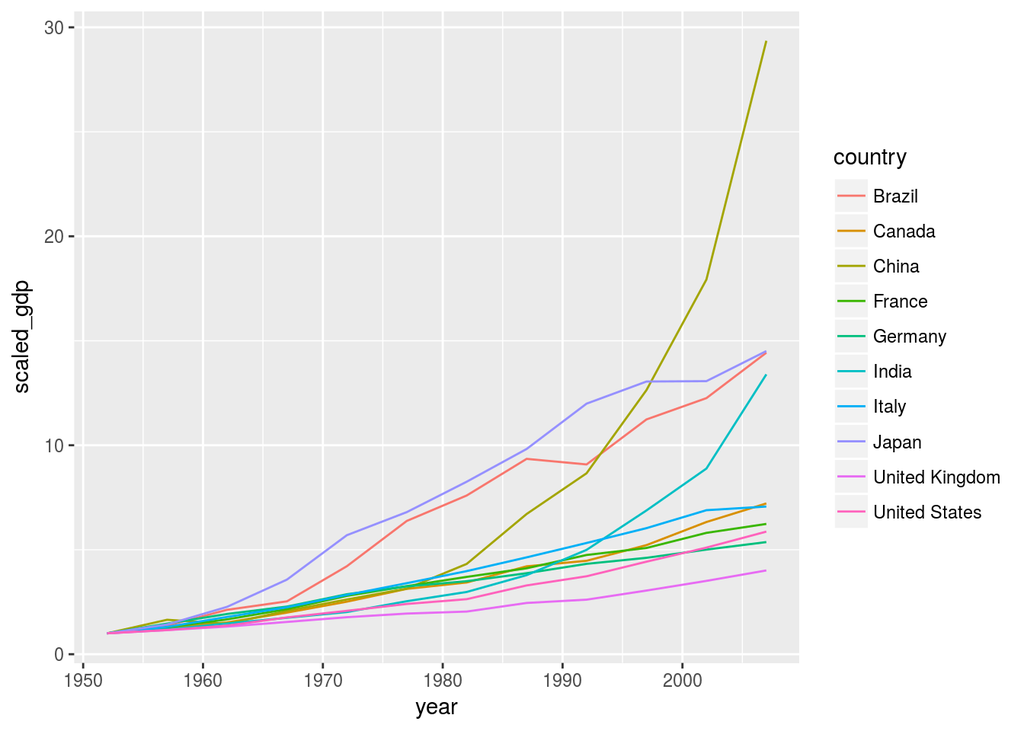

```r
gapminder %>%
  filter(country %in% top_10) %>%
  mutate(gdp = pop * gdpPercap) %>%
  group_by(country) %>%
  mutate(scaled_gdp = gdp / first(gdp)) %>%
  ggplot() +
    geom_line(mapping = aes(x = year, y = scaled_gdp, color = country))
```

### Cumulative Annual Growth Rates

```r
gapminder %>%
  filter(country %in% top_10) %>%
  mutate(gdp = pop * gdpPercap) %>%
  group_by(country) %>%
  summarise(start = first(gdp), end = last(gdp)) %>%
  mutate(cagr = ((end/start) ^ (1 / 55) - 1) * 100) %>%
  arrange(desc(cagr)) %>%
  select(country, cagr)
```

```
## # A tibble: 10 x 2
##           country     cagr
##            <fctr>    <dbl>
##  1          China 6.337334
##  2          Japan 4.983258
##  3         Brazil 4.973063
##  4          India 4.830628
##  5         Canada 3.658473
##  6          Italy 3.619402
##  7         France 3.383767
##  8  United States 3.269607
##  9        Germany 3.101929
## 10 United Kingdom 2.557105
```

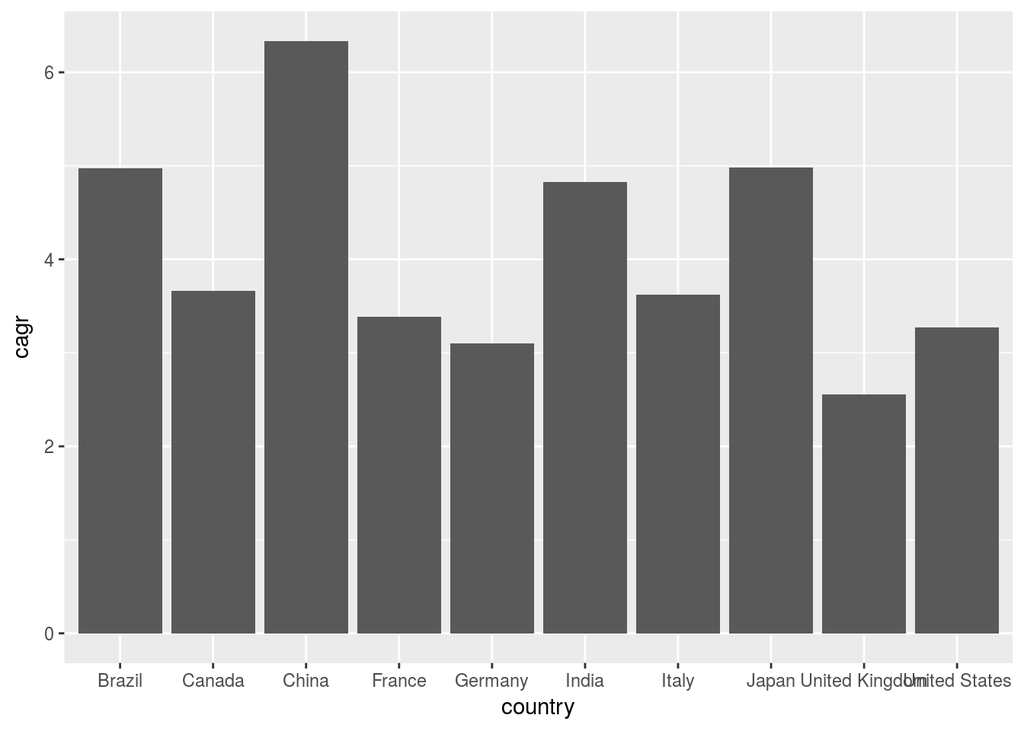

```r
gapminder %>%
  filter(country %in% top_10) %>%
  mutate(gdp = pop * gdpPercap) %>%
  group_by(country) %>%
  summarise(start = first(gdp), end = last(gdp)) %>%
  mutate(cagr = ((end/start) ^ (1 / 55) - 1) * 100) %>%
  arrange(desc(cagr)) %>%
  select(country, cagr) %>%
  ggplot() +
    geom_col(mapping = aes(x = country, y = cagr))
```

### Aspirational

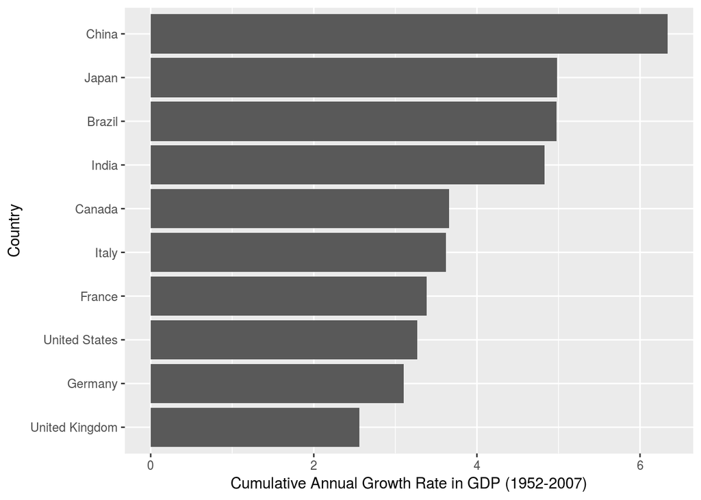

```r
library(forcats)

gapminder %>%
  filter(country %in% top_10) %>%
  mutate(gdp = pop * gdpPercap) %>%
  group_by(country) %>%
  summarise(start = first(gdp), end = last(gdp)) %>%
  mutate(cagr = ((end/start) ^ (1 / 55) - 1) * 100) %>%
  arrange(desc(cagr)) %>%
  ggplot() +
    geom_col(mapping = aes(x = fct_reorder(country, cagr), y = cagr)) +
    labs(x = "Country", y = "Cumulative Annual Growth Rate in GDP (1952-2007)") +
    coord_flip()
```